# Heatmap for homegardens

Cory Whitney

Homegarden studies often attempt to compare a collection of related variables. Heatmaps and cluster diagrams can be useful for this. Here is a way to get an overview of the relationships by generating intergrated plots in the [R programming language](https://www.r-project.org/) (R Core Team 2019).

Needless to say any aims objectives and hypotheses should be determined before any data is collected. Data visualization is a good time to get a clear sense for how your data looks, but is not the time to start making up hypotheses about it.

## Heatmap function

We use a garden heatmap function `heatmap.function` after [obigriffith’s heatmap.function](https://www.biostars.org/p/18211/). We use `grDevices` `terrain.colors` for filling the heatmap. Other colors can be chose from the `RColorBrewer` library (Neuwirth 2014).

## Simple heatmap

Here is an example for running the `heatmap.function` on a data set with few parameters.

```r
garden_matrix <- matrix(1:100, byrow = T, nrow = 10)

column_annotation <-
  sample(c("red", "blue", "green"), 10, replace = T)
column_annotation <- as.matrix(column_annotation)

colnames(column_annotation) <- c("Variable X")

row_annotation <- sample(c("red", "blue", "green"), 10, replace = T)
row_annotation <- as.matrix(t(row_annotation))

rownames(row_annotation) <- c("Variable Y")
```

Run the `heatmap.function` on the simple data.

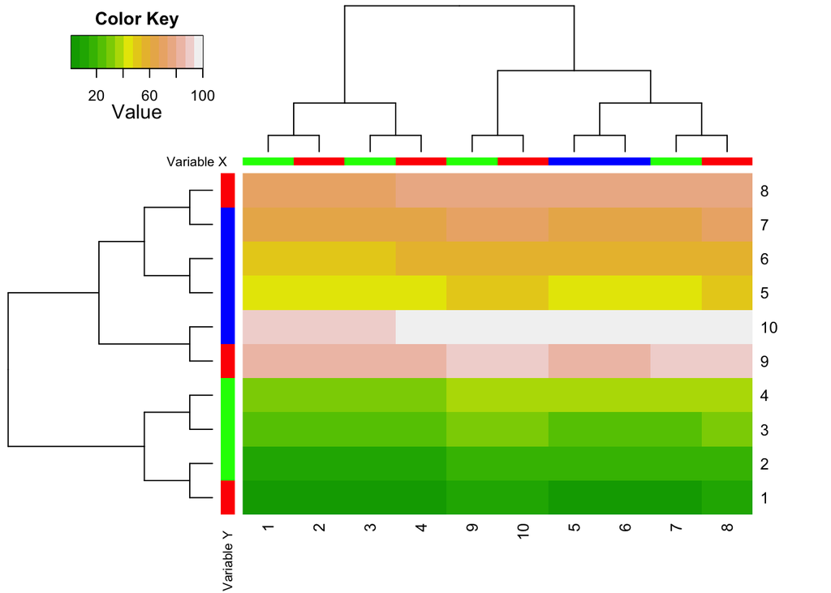

```r
heatmap.function(garden_matrix,
                 RowSideColors = row_annotation,
                 ColSideColors = column_annotation)
```

## Complex heatmap

Here is a more complex example with many parameters. First we create a dataset for demonstration purposes.

```r
plant_abundance = replicate(100, rnorm(20))
Garden_names = paste("Garden", letters[1:20], sep = "_")
Plant_ids = paste("Plant", c(1:100), sep = "_")
rownames(plant_abundance) = Garden_names
colnames(plant_abundance) = Plant_ids
```

Create color side bars to represent other variables to compare.

```r
owner_gendercolors = sample(
  c("darkorchid", "darkred"),
  length(Garden_names),
  replace = TRUE,
  prob = NULL
)
salescolors = sample(c("green", "darkgreen"),
                     length(Garden_names),
                     replace = TRUE,
                     prob = NULL)
subtypecolors = sample(
  c("red", "blue", "cyan", "pink", "yellow", "green"),
  length(Plant_ids),
  replace = TRUE,
  prob = NULL
)
qualitycolors = sample(c("black", "white", "grey"),
                       length(Plant_ids),
                       replace = TRUE,
                       prob = NULL)
yieldscolors = sample(c("black", "white", "grey"),
                      length(Plant_ids),
                      replace = TRUE,
                      prob = NULL)
Productioncolors = sample(c("black", "white", "grey"),
                          length(Plant_ids),
                          replace = TRUE,
                          prob = NULL)
Usefulnesscolors = sample(c("black", "white", "grey"),
                          length(Plant_ids),
                          replace = TRUE,
                          prob = NULL)
Importancecolors = sample(c("black", "white", "grey"),
                          length(Plant_ids),
                          replace = TRUE,
                          prob = NULL)
NutritionContributioncolors = sample(c("black", "white", "grey"),
                                     length(Plant_ids),
                                     replace = TRUE,
                                     prob = NULL)
```

Create labels

```r
rlab = t(cbind(owner_gendercolors, salescolors))

clab = cbind(
  subtypecolors,
  qualitycolors,
  yieldscolors,
  Productioncolors,
  Usefulnesscolors,
  Importancecolors,
  NutritionContributioncolors
)
```

Create row and column names.

```r
rownames(rlab) = c("Gender", "Economy")

colnames(clab) = c(
  "Subtype",
  "Quality",
  "Yield",
  "Production",
  "Usefulness",
  "Importance",
  "NutritionContribution"
)
```

Define `dist` and `hclust` functions for the heatmap using `stats` (R Core Team 2019).

```r
mydist=function(c) {dist(c,method="euclidian")}
myclust=function(c) {hclust(c,method="average")}
```

Create heatmap using the `heatmap.function`. Colors for the map are from `grDevices` `terrain.colors` (R Core Team 2019).

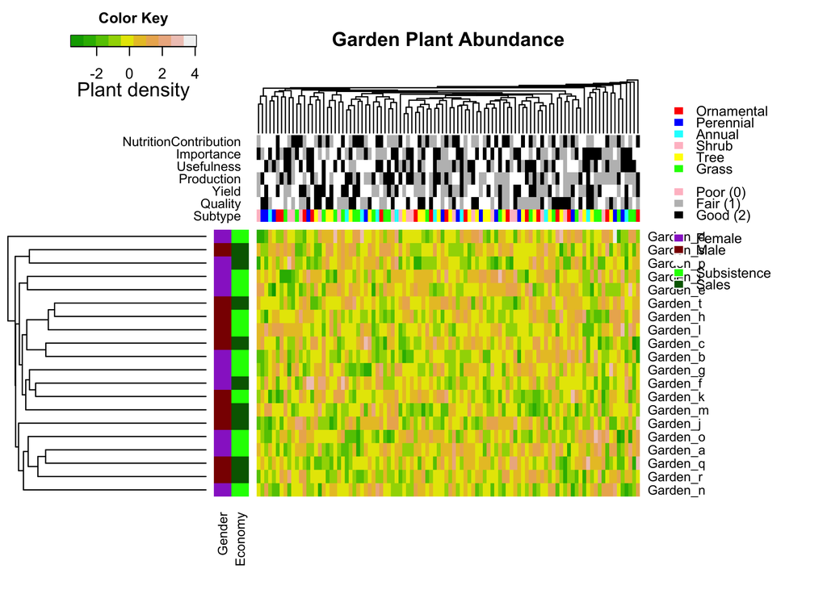

```r
main_title = "Garden Plant Abundance"

par(cex.main = 1)
heatmap.function(
  plant_abundance,
  hclustfun = myclust,
  distfun = mydist,
  na.rm = TRUE,
  scale = "none",
  dendrogram = "both",
  margins = c(6, 12),
  row_values = TRUE,
  cols_values = TRUE,
  ColSideColors = clab,
  RowSideColors = rlab,
  symbreaks = FALSE,
  key = TRUE,
  symkey = FALSE,
  density.info = "none",
  trace = "none",
  main = main_title,
  labCol = FALSE,
  labRow = Garden_names,
  cexRow = 1,
  col = terrain.colors(n=10, alpha=1),
  ColSideColorsSize = 7,
  RowSideColorsSize = 2,
  KeyValueName = "Plant density"
)
legend(
  "topright",
  legend = c(
    "Ornamental",
    "Perennial",
    "Annual",
    "Shrub",
    "Tree",
    "Grass",
    "",
    "Poor (0)",
    "Fair (1)",
    "Good (2)",
    "",
    "Female",
    "Male",
    "",
    "Subsistence",
    "Sales"
  ),
  fill = c(
    "red",
    "blue",
    "cyan",
    "pink",
    "yellow",
    "green",
    "white",
    "pink",
    "grey",
    "black",
    "white",
    "darkorchid",
    "darkred",
    "white",
    "green",
    "darkgreen"
  ),
  border = FALSE,
  bty = "n",
  y.intersp = 0.7,
  cex = 0.7
)
```

# Make an image file

Create a png of the heatmap using `grDevices` (R Core Team 2019) and `heatmap.function`.

```r
png(file="garden_heatmap.png")
main_title="Garden Plant Abundance"

par(cex.main=1)

heatmap.function(
  plant_abundance,
  hclustfun = myclust,
  distfun = mydist,
  na.rm = TRUE,
  scale = "none",
  dendrogram = "both",
  margins = c(6, 12),
  row_values = TRUE,
  cols_values = TRUE,
  ColSideColors = clab,
  RowSideColors = rlab,
  symbreaks = FALSE,
  key = TRUE,
  symkey = FALSE,
  density.info = "none",
  trace = "none",
  main = main_title,
  labCol = FALSE,
  labRow = Garden_names,
  cexRow = 1,
  col = terrain.colors(75),
  ColSideColorsSize = 7,
  RowSideColorsSize = 2,
  KeyValueName = "Prob. Response"
)
legend(
  "topright",
  legend = c(
    "Ornamental",
    "Perennial",
    "Annual",
    "Shrub",
    "Tree",
    "Grass",
    "",
    "Poor (0)",
    "Fair (1)",
    "Good (2)",
    "",
    "Female",
    "Male",
    "",
    "Subsistence",
    "Sales"
  ),
  fill = c(
    "red",
    "blue",
    "cyan",
    "pink",
    "yellow",
    "green",
    "white",
    "white",
    "grey",
    "black",
    "white",
    "darkorchid",
    "darkred",
    "white",
    "green",
    "darkgreen"
  ),
  border = FALSE,
  bty = "n",
  y.intersp = 0.7,
  cex = 0.7
)
dev.off()
```

## Ethnobotany heatmap

Following the simple example above we run the `heatmap.function` for visualizing data typical collected in ethnobotany surveys. We use the `ethnobotanydata` data set from `ethnobotanyR` (Whitney 2020).

```r
ethno_matrix <- as.matrix(dplyr::select(ethnobotanydata, -sp_name, -informant))
```

Run the `heatmap.function` on the simple data.

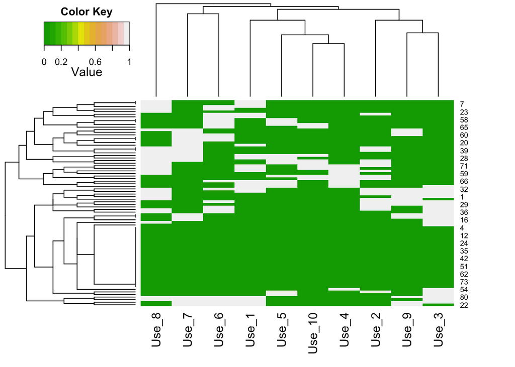

```r
heatmap.function(ethno_matrix)
```

# References

Neuwirth, Erich. 2014. *RColorBrewer: ColorBrewer Palettes*. https://CRAN.R-project.org/package=RColorBrewer.

R Core Team. 2019. *R: A Language and Environment for Statistical Computing*. Vienna, Austria: R Foundation for Statistical Computing. https://www.R-project.org/.

Whitney, Cory. 2020. *EthnobotanyR: Calculate Quantitative Ethnobotany Indices*. https://CRAN.R-project.org/package=ethnobotanyR.